# Lista de exercícios de Python

Cibele Castelo Nogueira

OBSERVAÇÂO:Respostas de perguntas fechadas foram dadas colocando em **NEGRITO** a resposta certa.

```python
from PIL import Image
```

## 2.15 Exercícios

###### Exercício 2.1 Digite a seguinte declaração no interpretador de Python e veja o que ele faz:

```python
5
x = 5
x+1
```

```
6
```

Exercício 2.2 Escreva um programa que use raw_input para perguntar a ele qual seu nome e dê as boas vindas ao usuário.

- Digite seu nome: Douglas
- Olá Douglas

```python
nome=str(input("Digite seu nome: "))
print("Olá", nome)
```

```
Digite seu nome: Douglas
Olá Douglas
```

###### Exercício 2.3 Escreva um programa no qual o usuário digite o número de horas trabalhadas e o valor pago por hora e calcule o salário bruto.

- Horas: 35
- Valor/hora: 2.75
- Salário Bruto : 96.25

```python
horas_trabalhadas=int(input("Digite número de horas trabalhadas"))
valor_pago=float(input("Digite o valor pago por hora"))

salario_bruto= horas_trabalhadas * valor_pago
print("Salário Bruto: ", salario_bruto)
```

```
Digite número de horas trabalhadas35
Digite o valor pago por hora2.75
Salário Bruto:  96.25
```

###### Exercício 2.4 Assuma as seguintes declarações de atribuição.

- largura = 17
- altura = 12.0

Para cada expressão a seguir, escreva o valor da expressão e o tipo (do valor da expressão).

1. largura/2
2. largura/2.0
3. altura/3
4. 1 + 2 *5

Use o interpretador de Python para verificar suas respostas.

```python
largura=17
altura=12.0

primeiro = largura/2
segundo = largura/2.0
terceiro = altura/3
quarto = 1 + 2 * 5

print("O valor da expressão é de", primeiro, "e o tipo do valor da expressão é float")
print("O valor da expressão é de", segundo, "e o tipo do valor da expressão é float")
print("O valor da expressão é de", terceiro, "e o tipo do valor da expressão é float")
print("O valor da expressão é de", quarto, "e o tipo do valor da expressão é int")
```

```
O valor da expressão é de 8.5 e o tipo do valor da expressão é float
O valor da expressão é de 8.5 e o tipo do valor da expressão é float
O valor da expressão é de 4.0 e o tipo do valor da expressão é float
O valor da expressão é de 11 e o tipo do valor da expressão é int
```

###### Exercício 2.5 Escreva um programa que toma como entrada uma temperatura em Celsius, converta-a em Fahrenheit e imprima a temperatura convertida.

```python
#tp_celsius= input("Digite a tempera em Celsiues: ")

def conversao(tp_celsius):

    temperatura=(tp_celsius * 9/5) + 32
    return temperatura
```

```python
print("O valor de Celsius 1 é equivalente a ", conversao(1), "fahrenheit")
```

```
O valor de Celsius 1 é equivalente a  33.8 fahrenheit
```

## 3.11 Exercícios

###### Exercício 3.1 Reescreva seu cálculo de pagamento para dar ao empregado 1,5 vezes o valor da hora para quem trabalhou acima de 40 horas.

- Entre com as horas: 45
- Entre com o valor da hora: 10
- Pagamento: 475.0

```python
horas_trabalhadas=int(input("Digite número de horas trabalhadas: "))
valor_pago=float(input("Digite o valor pago por hora: "))
hora_fixa=40
if horas_trabalhadas > 40:
    print("Pagamento: ", hora_fixa * valor_pago + (horas_trabalhadas - hora_fixa) * valor_pago * 1.5)

else:
    print("Pagamento: ", horas_trabalhadas * valor_pago)
```

```
Digite número de horas trabalhadas: 45
Digite o valor pago por hora: 10
Pagamento:  475.0
```

###### Exercício 3.2 Reescreva seu programa de pagamento usando try e except tal que seu programa trate a entrada não numérica, imprimindo uma mensagem e finalizando a execução do mesmo neste caso. O trecho a seguir mostra duas execuções do programa:

- Digite as horas: 20
- Digite o valor da hora: nine
- Erro! Por favor, digite uma entrada numérica.
- Entre com as horas: fourty
- Erro! Por favor, digite uma entrada numérica.

```python
try:
    horas_trabalhadas=int(input("Digite número de horas trabalhadas: "))
    valor_pago=float(input("Digite o valor pago por hora: "))

    if horas_trabalhadas > 40:
        print("Pagamento: ", horas_trabalhadas * (valor_pago * 1.5))

    else:
        print("Pagamento: ", horas_trabalhadas * valor_pago)

except:
    print("Erro!Por favor, digite uma entrada númerica.")
```

```
Digite número de horas trabalhadas: 20
Digite o valor pago por hora: nine
Erro!Por favor, digite uma entrada númerica.
```

###### Exercício 3.3 Escreva um programa que solicite um valor entre 0.0 e 1.0. Se o valor está fora do intervalo imprima um erro. Se o valor está entre 0.0 e 1.0, imprima um conceito de acordo com a tabela a seguir:

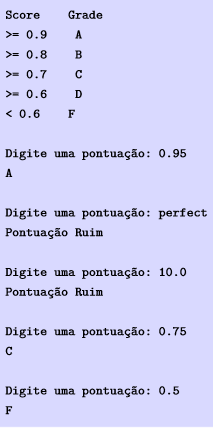

```python
pil_im= Image.open("scoregrade.png")
pil_im
```

```python
import numpy as np

valor = float(input("Digite um valor entre 0.0 e 1.0: "))

if valor not in [round(x * 0.1, 1) for x in range(0, 11)]:
    print("Valor está fora do intervalo")
    print("Pontuação ruim")


else:
    if valor >= 0.9:
        print("A")

    elif valor >= 0.8:
        print("B")

    elif valor >= 0.7:
        print("C")

    elif valor >= 0.6:
        print("D")

    else :
        print("F")
```

```
Digite um valor entre 0.0 e 1.0: 10
Valor está fora do intervalo
Pontuação ruim
```

```python
import numpy as np

valor = float(input("Digite um valor entre 0.0 e 1.0: "))

if valor not in [round(x * 0.1, 1) for x in range(0, 11)]:
    print("Valor está fora do intervalo")
    print("Pontuação ruim")


else:
    if valor >= 0.9:
        print("A")

    elif valor >= 0.8:
        print("B")

    elif valor >= 0.7:
        print("C")

    elif valor >= 0.6:
        print("D")

    else :
        print("F")
```

```
Digite um valor entre 0.0 e 1.0: 0.8
B
```

## 4.14 Exercícios

###### Exercício 4.1 Execute este programa no seu sistema e veja quais números foram gerados. Execute o programa mais de uma vez e veja quais números você obteve.

```python
import random
for i in range (10):
    x = random.random()
    print (x)
```

```
0.7049981776988046
0.646536289095819
0.1639649811036752
0.6744311214940139
0.5981253034041232
0.9154838821732695
0.9678557655852034
0.54391055900871
0.24809765479651513
0.8380845987904059
```

```python
import random
for i in range (10):
    x = random.random()
    print (x)
```

```
0.5107358598142026
0.5365285105220138
0.11309795278274348
0.5003079993563011
0.7584369186439769
0.8440712897445365
0.5011820056772303
0.18689885239730664
0.8315330772259724
0.14270956613814212
```

###### Exercício 4.2 Mova a última linha do programa anterior para o topo, de modo que a chamada às funções sejam realizadas antes das definições. Execute o programa e veja que mensagem de erro é retornada.

```python
#Mensagem de erro é retornada, pois não tem como chamar uma função se ela não foi criada
repeat_lyrics()
def print_lyrics():
    print ("I’m a lumberjack, and I’m okay.")
    print ("I sleep all night and I work all day.")
def repeat_lyrics():
    print_lyrics()
    print_lyrics()
```

```
---------------------------------------------------------------------------
NameError                                 Traceback (most recent call last)
<ipython-input-26-55d03d4f3688> in <module>()
      1 #Mensagem de erro é retornada, pois não tem como chamar uma função se ela não foi criada
----> 2 repeat_lyrics()
      3 def print_lyrics():
      4     print ("I’m a lumberjack, and I’m okay.")
      5     print ("I sleep all night and I work all day.")

NameError: name 'repeat_lyrics' is not defined
```

###### Exercício 4.3 Mova a chamada de função de volta para baixo remova a definição de print_lyrics após a definição de repeat_lyrics. O que acontece quando você executa este programa?

```python
# Desse modo, o programa consegue executar com sucesso!
def print_lyrics():
    print ("I’m a lumberjack, and I’m okay.")
    print ("I sleep all night and I work all day.")
def repeat_lyrics():
    print_lyrics()

repeat_lyrics()
```

```
I’m a lumberjack, and I’m okay.
I sleep all night and I work all day.
```

###### Exercício 4.4 Qual o propósito da palavra-chave def em Python?

a) É uma gíria que significa "o seguinte código é muito legal"

**b) Indica o começo de uma função**

c)Indica que a sequência de código identada seguinte deve ser armazenada para posterior utilização.

d) b e c são ambas verdadeiras e) n.d.a

###### Exercício 4.5 O que o programa a seguir imprime ?

def fred(): print("Zap")

def jane(): print("ABC")

jane() fred() jane()

a)Zap ABC jane fred jane

b)Zap ABC Zap

c)ABC Zap jane

**d)ABC Zap ABC**

e)Zap Zap Zap

###### Exercício 4.6 Reescreva o programa de computação de pagamento com um tempo e meio das horas extras e crie uma função chamada computepagamento que recebe dois parâmetros (o número de horas e o valor pago por hora).

Entre com as horas: 45

Entre com o valor da hora: 10

Pagamento: 675.0

```python
def computepagamento(horas_trabalhadas,valor_pago):

    try:
        if horas_trabalhadas > 40:
            print("Pagamento: ", horas_trabalhadas * (valor_pago * 1.5))
        else:
            print("Pagamento: ", horas_trabalhadas * valor_pago)
    except:
        print("Erro!Por favor, digite uma entrada númerica")
```

```python
computepagamento(45,10)
```

```
Pagamento:  675.0
```

###### Exercício 4.7 Reescreva o programa de notas do capítulo anterior usando uma função chamada computegrau que recebe uma pontuação como parâmetro e retorna um grau, sendo este último uma string.

Score Grade

- ">" 0.9 A
- ">" 0.8 B
- ">" 0.7 C
- ">" 0.6 D
- "<=" 0.6 F

Execução do Programa:

Entre com a pontuação: 0.95 A

Entre com a pontuação: perfeito Pontuação ruim

Entre com a pontuação: 10.0 Pontuação ruim

Entre com a pontuação: 0.75 C

Entre com a pontuação: 0.5 F

Execute o programa várias vezes para testar diferentes valores de entrada.

```python
import numpy as np

def pontuacao(valor):
    if valor not in [round(x * 0.1, 1) for x in range(0, 11)]:
        print("Valor está fora do intervalo")
        print("Pontuação ruim")


    else:
        if valor >= 0.9:
            print("A")

        elif valor >= 0.8:
            print("B")

        elif valor >= 0.7:
            print("C")

        elif valor >= 0.6:
            print("D")

        else :
            print("F")
```

```python
pontuacao(10)
```

```
Valor está fora do intervalo
Pontuação ruim
```

```python
pontuacao(0.7)
```

```
C
```

```python
pontuacao(0.2)
```

```
F
```

## 5.10 Exercícios

###### Exercício 5.1 Escreva um programa que leia números repetidamente até que o usuário informe “done”. Uma vez que “done” é informado, imprima a soma, quantidade e média dos números. Se o usuário digita alguma coisa diferente de um número, detecte o erro usando try e except e imprima uma mensagem de erro e pule para o próximo número.

- Digite um numero: 4
- Digite um numero: 5
- Digite um numero: bad data Invalid input
- Digite um numero: 7
- Digite um numero: done 16 3 5.33333333333

```python
soma=0
quantidade=0
try:
    while True:
        line = input ("Digite um número")

        if line == "done":
            break
        else:
            soma= int(line) + soma
            quantidade+=1
        print (line)

    media=soma/quantidade
    print ("Done!")
    print("A soma é:", soma)
    print("A quantidade é:", quantidade)
    print("A média é:", media)

except:
    print("Erro na digitação, favor digitar novamente um número")
    line = input ("Digite um número")
```

```
Digite um número7
7
Digite um número4
4
Digite um número3
3
Digite um númerodone
Done!
A soma é: 14
A quantidade é: 3
A média é: 4.666666666666667
```

###### Exercício5.2 Escreva um programa que pede por uma lista de números e imprima o maior e o menor dos números. Sua entrada deve respeitar as condições impostas no Exercício 5.1.

```python
try:
    lista = [int(x) for x in input("Digite uma lista de números").split()]
    print("O valor máximo da lista é de: " , max(lista))
    print("O valor minimo da lista é de: " , min(lista))
except:
    print("Erro: Favor digitar novamente uma lista com valores númericos")
    lista = [int(x) for x in input("Digite uma lista de números").split()]
```

```
Digite uma lista de números40 100 600 30
O valor máximo da lista é de:  600
O valor minimo da lista é de:  30
```

## 6.14 Exercícios

###### Exercício6.1 Escreva uma estrutura de repetição usando o laço while que comece no último caractere da string e funcione de trás para frente até o primeiro caractere, exibindo cada letra em uma linha separada.Outro modo de se escrever um percurso sobre uma string é usando uma estrutura de repetição for:

```python
indice=0
fruta='abacaxi'
fruta=fruta[::-1]
for letras in fruta:
    letras.split()
    print (letras)
```

```
i
x
a
c
a
b
a
```

###### Exercício 6.2 Sabendo que fruta é uma string, o que fruta[:] significa?

Ao colocar fruta[:], isso significa que todos os caracteres vão ser retornados.

###### Exercício 6.3 Crie uma função chamada count, que recebe uma palavra p e um caracter c como entrada. Como saída, mostre o número de ocorrências do caracter c na palavra p.

```python
def count(p,c):
    contador=p.count(c)
    return contador
```

```python
count("cibele","e")
```

```
2
```

###### Exercício 6.4Existe um método chamado count que é similar à função do último exercício. Leia a explicação desse método em docs.python.org/library/string.html e escreva uma invocação que conte quantas vezes a letra a aparece em ’banana’

```python
count("banana","a")
```

```
3
```

###### Exercicio 6.5 Dado o código a seguir que armazena uma string:

```python
string = "X-DSPAM-Confidence: 0.8475"
```

Use o método find e fragmente a string para extrair a porção da string depois dos dois pontos e então use a função float para converter a string extraída em um número com ponto flutuante.

```python
string=string.strip()
atpos=string.find(":")
print (atpos)
```

```
18
```

```python
sppos = string.find("5",atpos)
print(sppos)
```

```
25
```

```python
host = float(string[atpos + 1: sppos])
host = float(string[atpos + 1: sppos])
print ("Resultado da string fragmentada {:.2f}".format(host))
```

```
Resultado da string fragmentada 0.85
```

###### Exercicio 6.6 Leia o documento sobre os métodos de string no endereço3. Você pode querer experimentar algum deles para ter certeza de que funcionam strip e replace são bastante úteis. A documentação disponível no site usa uma sintaxe que pode confundí-lo. Por exemplo, em find(sub[,start[, end]]), os colchetes indicam argumentos opcionais. Então sub é requerido, porém start é opcional, e se você incluir o start, então o end é opcional

```python
texto = "0000000isto é um exemplo....wow!!!0000000"
texto.strip( '0' )
```

```
'isto é um exemplo....wow!!!'
```

## 7.11 Exercícios

```python
fhand = open("mbox-short.txt")
for line in fhand:
    line = line.upper()
    #print(line)         #retirar o comentário para mostrar o arquivo impresso
```

###### Exercício 7.2:

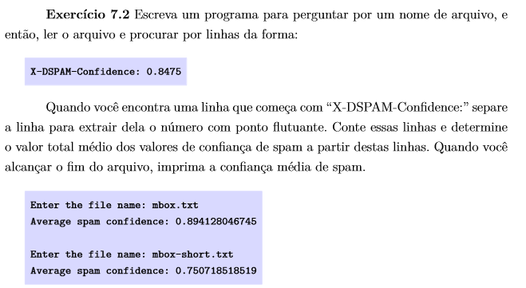

```python
pil_im= Image.open("7.2.png")
pil_im
```

```python
#NOME DO ARQUIVO mbox.txt

fname = input("Entre como nome do arquivo:" )

try:
    fhand = open(fname)
except:
    print ("File cannot be opened:", fname )
    exit()
count=0
soma=0

for line in fhand:

    if line.startswith("X-DSPAM-Confidence:"):
        line=line.strip()
        atpos=line.find(":")
        sppos=line.find("5,atpos")
        host = float(line[atpos + 1: sppos])
        host = float(line[atpos + 1: sppos])
        print ("Resultado da string fragmentada {:.2f}".format(host))
        count+=1
        soma=soma + host


average_spam_confidence=soma/count
print ("Existe no documento a quantidade de",count,"strings fragmentadas.")
print (soma)
print("A average_spam_confidence=soma é de: ", average_spam_confidence)
```

```
Entre como nome do arquivo:mbox.txt
Resultado da string fragmentada 0.85
Resultado da string fragmentada 0.62
Resultado da string fragmentada 0.70
Resultado da string fragmentada 0.76
Resultado da string fragmentada 0.76
Resultado da string fragmentada 0.76
Resultado da string fragmentada 0.70
Resultado da string fragmentada 0.76
Resultado da string fragmentada 0.76
Resultado da string fragmentada 0.76
Resultado da string fragmentada 0.69
Resultado da string fragmentada 0.76
Resultado da string fragmentada 0.76
Resultado da string fragmentada 0.76
Resultado da string fragmentada 0.69
Resultado da string fragmentada 0.76
Resultado da string fragmentada 0.65
Resultado da string fragmentada 0.69
Resultado da string fragmentada 0.65
Resultado da string fragmentada 0.70
Resultado da string fragmentada 0.76
Resultado da string fragmentada 0.69
Resultado da string fragmentada 0.69
Resultado da string fragmentada 0.76
Resultado da string fragmentada 0.98
Resultado da string fragmentada 0.85
Resultado da string fragmentada 0.99
Resultado da string fragmentada 0.70
Resultado da string fragmentada 0.85
Resultado da string fragmentada 0.99
Resultado da string fragmentada 1.00
Resultado da string fragmentada 0.99
Resultado da string fragmentada 0.99
Resultado da string fragmentada 0.99
Resultado da string fragmentada 0.70
Resultado da string fragmentada 0.99
Resultado da string fragmentada 0.99
Resultado da string fragmentada 0.85
Resultado da string fragmentada 0.76
```

[output cut: 1746 more lines]

```
Resultado da string fragmentada 0.85
Resultado da string fragmentada 0.85
Resultado da string fragmentada 0.85
Resultado da string fragmentada 0.99
Resultado da string fragmentada 0.99
Resultado da string fragmentada 0.85
Resultado da string fragmentada 0.98
Resultado da string fragmentada 0.98
Resultado da string fragmentada 0.98
Resultado da string fragmentada 0.99
Resultado da string fragmentada 0.98
Resultado da string fragmentada 0.98
Existe no documento a quantidade de 1797 strings fragmentadas.
1605.9539999999968
A average_spam_confidence=soma é de:  0.8936861435726192
```

```python
#NOME DO ARQUIVO mbox-shot.txt

fname = input("Entre como nome do arquivo:" )

try:
    fhand = open(fname)
except:
    print ("File cannot be opened:", fname )
    exit()
count=0
soma=0

for line in fhand:

    if line.startswith("X-DSPAM-Confidence:"):
        line=line.strip()
        atpos=line.find(":")
        sppos=line.find("5,atpos")
        host = float(line[atpos + 1: sppos])
        host = float(line[atpos + 1: sppos])
        print ("Resultado da string fragmentada {:.2f}".format(host))
        count+=1
        soma=soma + host


average_spam_confidence=soma/count
print ("Existe no documento a quantidade de",count,"strings fragmentadas.")
print (soma)
print("A average_spam_confidence=soma é de: ", average_spam_confidence)
```

```
Entre como nome do arquivo:mbox-short.txt
Resultado da string fragmentada 0.85
Resultado da string fragmentada 0.62
Resultado da string fragmentada 0.70
Resultado da string fragmentada 0.76
Resultado da string fragmentada 0.76
Resultado da string fragmentada 0.76
Resultado da string fragmentada 0.70
Resultado da string fragmentada 0.76
Resultado da string fragmentada 0.76
Resultado da string fragmentada 0.76
Resultado da string fragmentada 0.69
Resultado da string fragmentada 0.76
Resultado da string fragmentada 0.76
Resultado da string fragmentada 0.76
Resultado da string fragmentada 0.69
Resultado da string fragmentada 0.76
Resultado da string fragmentada 0.65
Resultado da string fragmentada 0.69
Resultado da string fragmentada 0.65
Resultado da string fragmentada 0.70
Resultado da string fragmentada 0.76
Resultado da string fragmentada 0.69
Resultado da string fragmentada 0.69
Resultado da string fragmentada 0.76
Resultado da string fragmentada 0.98
Resultado da string fragmentada 0.85
Resultado da string fragmentada 0.99
Existe no documento a quantidade de 27 strings fragmentadas.
20.254
A average_spam_confidence=soma é de:  0.7501481481481482
```

###### Exercício 7.3

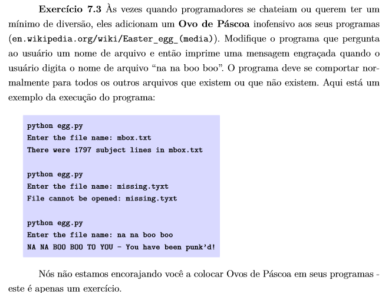

```python
pil_im= Image.open("7.3.png")
pil_im
```

```python
fname = input("Entre como nome do arquivo:" )

try:
    fhand = open(fname)
except:
    if fname == "na na boo boo":
        print ("NA NA BOO BOO TO YOU - You have been punk’d!")
    else:
        print ("File cannot be opened:", fname )
    exit()
```

```
Entre como nome do arquivo:mbox.txt
```

```python
fname = input("Entre como nome do arquivo:" )

try:
    fhand = open(fname)
except:
    if fname == "na na boo boo":
        print ("NA NA BOO BOO TO YOU - You have been punk’d!")
    else:
        print ("File cannot be opened:", fname )
    exit()
```

```
Entre como nome do arquivo:missing.tyx
File cannot be opened: missing.tyx
```

```python
fname = input("Entre como nome do arquivo:" )

try:
    fhand = open(fname)
except:
    if fname == "na na boo boo":
        print ("NA NA BOO BOO TO YOU - You have been punk’d!")
    else:
        print ("File cannot be opened:", fname )
    exit()
```

```
Entre como nome do arquivo:na na boo boo
NA NA BOO BOO TO YOU - You have been punk’d!
```

## 8.16 Exercícios

###### Exercício 8.1

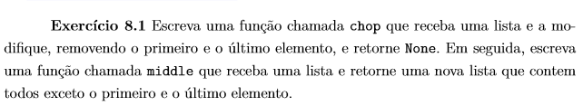

```python
pil_im= Image.open("8.1.png")
pil_im
```

```python
def chop(lista):
    del lista[0]
    del lista [-1]
    return lista
```

```python
def middle(listaa):
    listaa=chop(listaa)
    return listaa
```

```python
middle([1,2,3,4,5,6,7,8,9,10,11,12])
```

```
[2, 3, 4, 5, 6, 7, 8, 9, 10, 11]
```

###### Exercicio 8.2

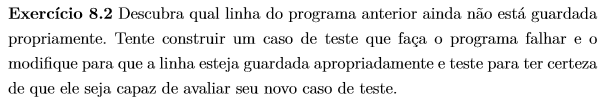

```python
pil_im= Image.open("8.2.png")
pil_im
```

```python
fhand = open("mbox-short.txt")
for line in fhand:
    palavras = line.split()
    #print ("Debug:", palavras )
    if len(palavras) == 0 :
        continue
    if palavras[0] != "From" :
        continue
    print (palavras[2])
```

```
Sat
Fri
Fri
Fri
Fri
Fri
Fri
Fri
Fri
Fri
Fri
Fri
Fri
Fri
Fri
Fri
Fri
Fri
Fri
Fri
Fri
Thu
Thu
Thu
Thu
Thu
Thu
```

###### Exercicio 8.3

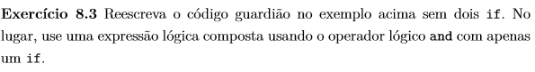

```python
pil_im= Image.open("8.3.png")
pil_im
```

```python
arquivo = open("mbox-short.txt")
for line in arquivo:
    palavras = line.split()
    if len(palavras) > 0 and palavras[0] == "From": continue
    print (palavras[1])
```

```
<postmaster@collab.sakaiproject.org>
from
frankenstein.mail.umich.edu
05
CMU
from
mail.umich.edu
05
from
flawless.mail.umich.edu
5
FROM
holes.mr.itd.umich.edu
Jan
from
paploo.uhi.ac.uk
5
<200801051412.m05ECIaH010327@nakamura.uits.iupui.edu>
1.0
7bit
from
paploo.uhi.ac.uk
<source@collab.sakaiproject.org>;
5
from
shmi.uhi.ac.uk
<source@collab.sakaiproject.org>;
from
nakamura.uits.iupui.edu
<source@collab.sakaiproject.org>;
(from
nakamura.uits.iupui.edu
source@collab.sakaiproject.org;
Sat,
nakamura.uits.iupui.edu:
source@collab.sakaiproject.org
stephen.marquard@uct.ac.za
[sakai]
text/plain;
text/plain;
text/plain;
Innocent
Sat
0.8475
0.0000
```

```
---------------------------------------------------------------------------
IndexError                                Traceback (most recent call last)
<ipython-input-63-b6a4a81021b5> in <module>()
      3     palavras = line.split()
      4     if len(palavras) > 0 and palavras[0] == "From": continue
----> 5     print (palavras[1])

IndexError: list index out of range
```

###### Exercício 8.4

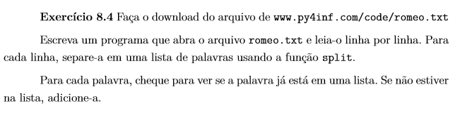

```python
pil_im= Image.open("8.4.png")
pil_im2= Image.open("8.44.png")
pil_im
```

```python
fname = ("romeo.txt")
fhand = open(fname)
```

```python
listone = [1,2,3]
listtwo = [4,5,6]
mergedlist = []
mergedlist.extend(listone)
mergedlist.extend(listtwo)
mergedlist
```

```
[1, 2, 3, 4, 5, 6]
```

```python
for line in fhand:
    for palavras in line:
        lista=[]
        palavras = line.split()
        lista.append(line)
    print (lista)
```

```
['But soft what light through yonder window breaks\n']
['It is the east and Juliet is the sun\n']
['Arise fair sun and kill the envious moon\n']
['Who is already sick and pale with grief\n']
```

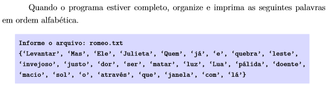

```python
pil_im2
```

```python
for line in fhand:
    for palavras in line:
        palavras = line.split()
        palavras.sort(reverse=False)
    print (palavras)
```

```
['But', 'breaks', 'light', 'soft', 'through', 'what', 'window', 'yonder']
['It', 'Juliet', 'and', 'east', 'is', 'is', 'sun', 'the', 'the']
['Arise', 'and', 'envious', 'fair', 'kill', 'moon', 'sun', 'the']
['Who', 'already', 'and', 'grief', 'is', 'pale', 'sick', 'with']
```

###### Exercício 8.5

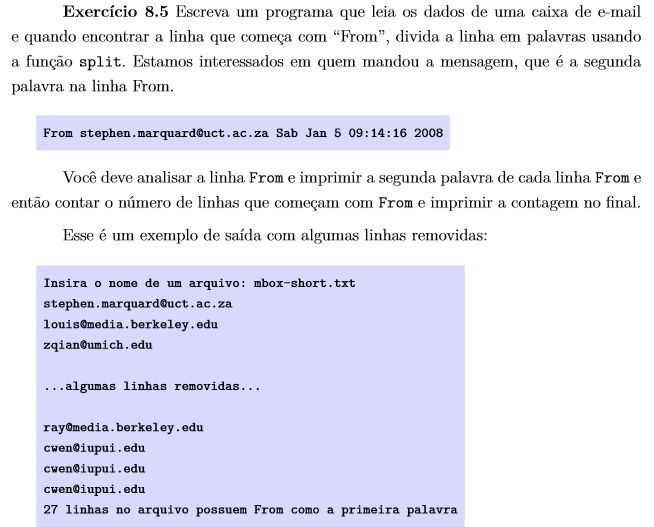

```python
pil_im= Image.open("8.5.png")
pil_im
```

```python
fhand = open("mbox-short.txt")
count=0
for line in fhand:
    if line.startswith("From "):
        palavras = line.split()
        count+=1
        print(palavras[1])
print(count,"linhas no arquivo possuem FROM como a primeira palavra")
```

```
stephen.marquard@uct.ac.za
louis@media.berkeley.edu
zqian@umich.edu
rjlowe@iupui.edu
zqian@umich.edu
rjlowe@iupui.edu
cwen@iupui.edu
cwen@iupui.edu
gsilver@umich.edu
gsilver@umich.edu
zqian@umich.edu
gsilver@umich.edu
wagnermr@iupui.edu
zqian@umich.edu
antranig@caret.cam.ac.uk
gopal.ramasammycook@gmail.com
david.horwitz@uct.ac.za
david.horwitz@uct.ac.za
david.horwitz@uct.ac.za
david.horwitz@uct.ac.za
stephen.marquard@uct.ac.za
louis@media.berkeley.edu
louis@media.berkeley.edu
ray@media.berkeley.edu
cwen@iupui.edu
cwen@iupui.edu
cwen@iupui.edu
27 linhas no arquivo possuem FROM como a primeira palavra
```

###### Exercício 8.6

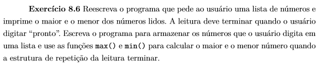

```python
pil_im= Image.open("8.6.png")
pil_im2= Image.open("8.66.png")
pil_im
```

```python
lista=[]
while True:
        line = input ("Digite um número")

        if line == "pronto":
            break
        lista.append(line)
maior=max(lista)
menor=min(lista)
print("O menor número é: ", menor)
print("O maior número é:", maior)
```

```
Digite um número90
Digite um número30
Digite um número70
Digite um númeropronto
O menor número é:  30
O maior número é: 90
```

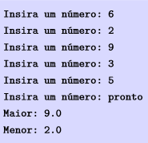

```python
pil_im2
```

## 9.7 Exercícios

###### Exercício 9.1 Escreva um programa que leia palavras em words.txt e as armazene como chaves em um dicionário. Não importa o que os valores são. Então você pode usar o operador in como um meio rápido de verificar se uma string está no dicionário.

```python
fhand = open("words.txt")
dic={}
for line in fhand:
    key = line.split()
    dic[str(key)] = key
```

```python
dic
```

```
{"['baccarats']": ['baccarats'],
 "['balladeer']": ['balladeer'],
 "['ballasted']": ['ballasted'],
 "['barracked']": ['barracked'],
 "['barracuda']": ['barracuda'],
 "['barraging']": ['barraging'],
 "['battalion']": ['battalion'],
 "['bettering']": ['bettering'],
 "['billiards']": ['billiards'],
 "['billionth']": ['billionth'],
 "['borrowers']": ['borrowers'],
 "['borrowing']": ['borrowing'],
 "['bottoming']": ['bottoming'],
 "['collocate']": ['collocate'],
 "['colloidal']": ['colloidal'],
 "['colloquia']": ['colloquia'],
 "['commodity']": ['commodity'],
 "['commodore']": ['commodore'],
 "['commoners']": ['commoners'],
 "['commonest']": ['commonest'],
 "['commotion']": ['commotion'],
 "['connoting']": ['connoting'],
 "['corroding']": ['corroding'],
 "['corrosion']": ['corrosion'],
 "['corrosive']": ['corrosive'],
 "['cottoning']": ['cottoning'],
 "['difficult']": ['difficult'],
 "['diffident']": ['diffident'],
 "['dissident']": ['dissident'],
 "['dissipate']": ['dissipate'],
 "['dizziness']": ['dizziness'],
 "['doggonest']": ['doggonest'],
 "['doggoning']": ['doggoning'],
 "['dolloping']": ['dolloping'],
 "['fallacies']": ['fallacies'],
 "['farragoes']": ['farragoes'],
 "['ferreting']": ['ferreting'],
 "['fettering']": ['fettering'],
 "['filliping']": ['filliping'],
 "['fittingly']": ['fittingly'],
```

[output cut: 58 more lines]

```
 "['suppurate']": ['suppurate'],
 "['tarragons']": ['tarragons'],
 "['tinniness']": ['tinniness'],
 "['tittivate']": ['tittivate'],
 "['vassalage']": ['vassalage'],
 "['wallabies']": ['wallabies'],
 "['warranted']": ['warranted'],
 "['wassailed']": ['wassailed'],
 "['willingly']": ['willingly'],
 "['williwaws']": ['williwaws'],
 "['winningly']": ['winningly'],
 "['witticism']": ['witticism'],
 "['wittiness']": ['wittiness'],
 "['wittingly']": ['wittingly'],
 "['zeppelins']": ['zeppelins']}
```

###### Exercício 9.3

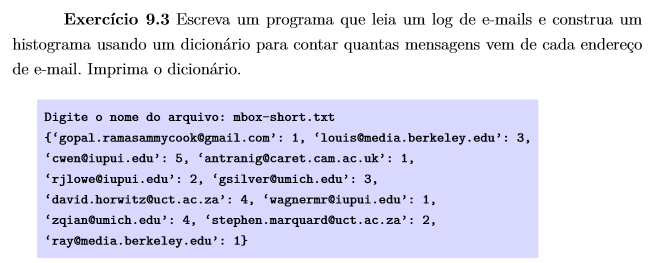

```python
pil_im= Image.open("9.3.png")
pil_im
```

```python
fhand = open("mbox-short.txt")
dic={}
for line in fhand:
    if line.startswith("From "):
        palavras = line.split()
        key = palavras[1].split()
        dic[str(key)] = key

print(dic)
```

[output not shown]

```python
fhand = open("mbox-short.txt")
dic={}
for line in fhand:
    if line.startswith("From "):
        palavras = line.split()
        key = palavras[1].split()
        for c in key:
            if c not in dic:
                dic[c]=1
            else:
                dic[c]+=1
print(dic)
```

[output not shown]

```python
valores=dic.values()
valores
```

```
dict_values([2, 3, 4, 2, 5, 3, 1, 1, 1, 4, 1])
```

###### Exercício 9.4

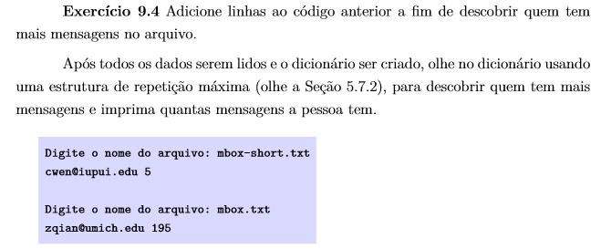

```python
pil_im= Image.open("9.4.png")
pil_im
```

```python
fhand = open("mbox-short.txt")
dic={}
maior=None
for line in fhand:
    if line.startswith("From "):
        palavras = line.split()
        key = palavras[1].split()
        #dic[str(key)] = key
        for c in key:
            if c not in dic:
                dic[c]=1
            else:
                dic[c]+=1

        for intervalo in dic.values():
            if maior is None or intervalo > maior:
                maior=intervalo
                key=dic.get(maior)

print("O maior é: ",maior)
dic
```

```
O maior é:  5
```

```
{'antranig@caret.cam.ac.uk': 1,
 'cwen@iupui.edu': 5,
 'david.horwitz@uct.ac.za': 4,
 'gopal.ramasammycook@gmail.com': 1,
 'gsilver@umich.edu': 3,
 'louis@media.berkeley.edu': 3,
 'ray@media.berkeley.edu': 1,
 'rjlowe@iupui.edu': 2,
 'stephen.marquard@uct.ac.za': 2,
 'wagnermr@iupui.edu': 1,
 'zqian@umich.edu': 4}
```

###### Exercício 9.5

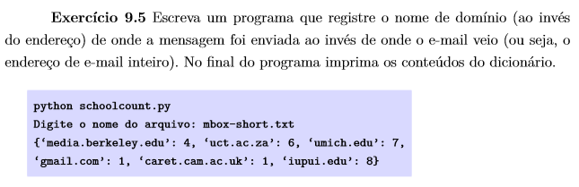

```python
pil_im= Image.open("9.5.png")
pil_im
```

```python
fhand = open("mbox-short.txt")
dic={}
for line in fhand:
    if line.startswith("From"):
        line=line.strip()
        atpos=line.find("@")
        sppos = line.find(" ",atpos)
        host = line[atpos+1:sppos]
        key = host.split()
        for c in key:
            if c not in dic:
                dic[c]=1
            else:
                dic[c]+=1

dic
```

```
{'caret.cam.ac.u': 1,
 'caret.cam.ac.uk': 1,
 'gmail.co': 1,
 'gmail.com': 1,
 'iupui.ed': 8,
 'iupui.edu': 8,
 'media.berkeley.ed': 4,
 'media.berkeley.edu': 4,
 'uct.ac.z': 6,
 'uct.ac.za': 6,
 'umich.ed': 7,
 'umich.edu': 7}
```

## 10.11 Exercícios

###### Exercício 10.1 Revise o programa anterior como segue: Leia e analise as linhas “From” e extraia os endereços de cada linha. Conte o número de mensagens de cada pessoa usando um dicionário. Após todos os dados terem sido lidos, imprima a pessoa com mais submissões (commits) através da criação de uma lista de tuplas (contador, e-mail) do dicionário e então ordena a lista em ordem decrescente e imprima a pessoa que tem mais submissões.

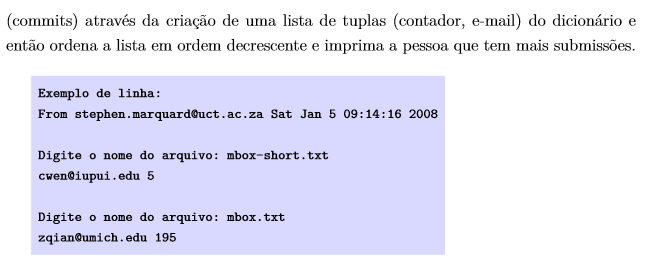

```python
pil_im= Image.open("10.1.png")
pil_im
```

```python
import operator
fhand = open("mbox-short.txt")
dic={}
maior=None
for line in fhand:
    if line.startswith("From "):
        palavras = line.split()
        key = palavras[1].split()
        for c in key:
            if c not in dic:
                dic[c]=1
            else:
                dic[c]+=1


lista_dic = list(dic.items())
lista_dic_ordenacao = sorted(lista_dic, key=operator.itemgetter(1))
lista_dic_ordenacao.reverse()
lista_dic_ordenacao[0]
```

```
('cwen@iupui.edu', 5)
```

```python
import operator
fhand = open("mbox.txt")
dic={}

for line in fhand:
    if line.startswith("From "):
        palavras = line.split()
        key = palavras[1].split()
        for c in key:
            if c not in dic:
                dic[c]=1
            else:
                dic[c]+=1


lista_dic = list(dic.items())
lista_dic_ordenacao = sorted(lista_dic, key=operator.itemgetter(1))
lista_dic_ordenacao.reverse()
lista_dic_ordenacao[0]
```

```
('zqian@umich.edu', 195)
```

###### Exercício 10.2

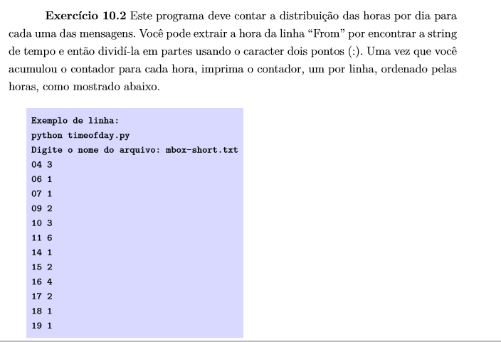

```python
pil_im= Image.open("10.2.png")
pil_im
```

```python
fhand = open("mbox-short.txt")
horas={}
for line in fhand:
    if line.startswith("From"):
        line=line.strip()
        atpos=line.find(":")
        host = line[atpos-2:atpos]
        key = host.split()
        for c in key:
            if c not in horas:
                horas[c]=1
            else:
                horas[c]+=1

horas
```

```
{'04': 3,
 '06': 1,
 '07': 1,
 '09': 2,
 '10': 3,
 '11': 6,
 '14': 1,
 '15': 2,
 '16': 4,
 '17': 2,
 '18': 1,
 '19': 1,
 'om': 27}
```

###### Exercício 10.3

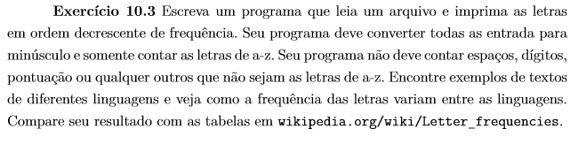

```python
pil_im= Image.open("10.3.png")
pil_im
```

```python
import re
import collections
fhand = open("mbox-short.txt")
dicionario={}
for line in fhand:
    line=line.lower()
    line=line.replace('\n', '')
    line=line.replace('\t', '')
    line.strip()
    letras=list(line)
    for letra in letras:
        if letra >= 'a' and letra <= 'z':
            if letra in dicionario:
                dicionario[letra]+=1
            else:
                dicionario[letra]=1

lista=[]
for d in dicionario:
    conjunto= (d,dicionario[d])
    lista.append(conjunto)
lista.sort()
lista
```

```
[('a', 5223),
 ('b', 1134),
 ('c', 3088),
 ('d', 2004),
 ('e', 5436),
 ('f', 1257),
 ('g', 1027),
 ('h', 1392),
 ('i', 4494),
 ('j', 959),
 ('k', 1167),
 ('l', 1832),
 ('m', 2436),
 ('n', 2575),
 ('o', 4174),
 ('p', 2497),
 ('q', 57),
 ('r', 4064),
 ('s', 3738),
 ('t', 4050),
 ('u', 3123),
 ('v', 997),
 ('w', 586),
 ('x', 482),
 ('y', 643),
 ('z', 78)]
```